# Tugas Pak Farit

Angga Fathan Rofiqy

06 May, 2024

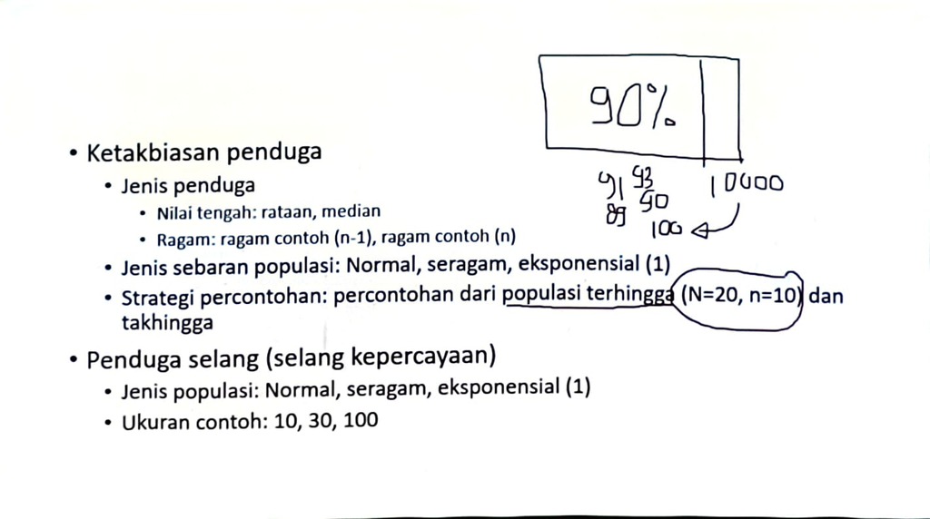

# 1 Ketakbiasan Penduga

## 1.1 Jenis sebaran populasi (takhingga)

Jenis sebaran populasi yang akan saya gunakan kali ini adalah populsi **takhingga**. Ini mengasumsikan bahwa populasinya merupakan sebuah populasi takhingga yang menyebar suatu sebaran, misalnya menyebar eksponensial.

Sejalan dengan fungsi pembangkit bilaganan acak dalam R merupakan sampling dari sebaran asli. Sehingga ketika kita melakukan pembangkitan bilangan acak, itu bisa langsung dianggap sampling jika langsung menggunakan fungsi pembangkit bilangan acak seperti `rexp`. Ini tidak berlaku jika kita mencampur fungsi nya.

Kali ini saya akan sampling dengan langsung membangkitkan bilangan acaknya dengan fungsi yang sudah tersedia (`rnorm`, `runif`, `rexp` dsb). Saya akan mencoba 3 sebaran, yakni sebaran Normal, Seragam, dan Eksponensial(1). Ukuran contoh (n) yang akan saya gunakan untuk setiap sebaran adalah 10, dengan ulangan untuk simulasi (k) = 1000.

Saya menentukan parameter populasi untuk sebaran setiap sebaran sebagai berikut:

| Sebaran | Nilai tengah | Ragam |
| --- | --- | --- |
| Normal (60, 16) | $\mu=60$ | $\sigma^2=16$ |
| Seragam (0, 1) | $\frac{a+b}{2}=0.5$ | $\frac{(b-a)^2}{12} \approx 0.08334$ |
| Eksponensial (1) | $\theta=1$ | $\theta^2=1$ |

Dimana a=0, dan b=1 untuk Seragam(0, 1). Namun ada perbedaan dalam fungsi r, yakni pada fungsi `rnorm` parameternya adalah `rnorm(n, mean, sd)`, sehingga `sd` yang saya tetapkan adalah $\sqrt{16}=4$. Lalu pada fungsi `rexp` parameternya adalah `rexp(n, rate = 1)`, dimana `rate` = $\frac{1}{\theta}$, sehingga semakin besar rate, maka akan semakin kecil selisih min max pada sebaran eksponensial.

> Berikut merupakan hasil dari simulasi pembangkitan bilangan acak nya:

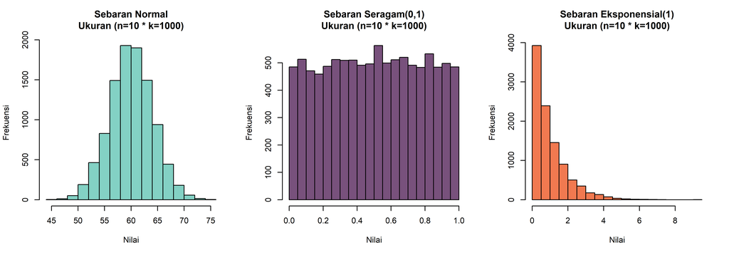

```r
set.seed(361)
# k=ulangan simulasi, n=sample
k = 1000; n = 10

par(mfrow = c(1, 3))
# Sebaran Normal
norm_sample <- matrix(rnorm(n*k, mean=60, sd=4), n)

hist(norm_sample,
     main = paste0("Sebaran Normal\nUkuran (n=", n," * k=", k, ")"),
     xlab = "Nilai", ylab = "Frekuensi", col = "#83D1C4")

# Sebaran Seragam(0,1)
unif_sample <- matrix(runif(n*k, min=0, max=1), n)

hist(unif_sample,
     main = paste0("Sebaran Seragam(0,1)\nUkuran (n=", n," * k=", k, ")"),
     xlab = "Nilai", ylab = "Frekuensi", col = "#78517C")

# Sebaran Eksponensial(1)
exp_sample <- matrix(rexp(n*k, rate=1), n)

hist(exp_sample,
     main = paste0("Sebaran Eksponensial(1)\nUkuran (n=", n," * k=", k, ")"),
     xlab = "Nilai", ylab = "Frekuensi", col = "#F17950")
```

Bentuk sebarannya sangat seperti sebaran normal/seragam/eksponensial. Ini berkat banyaknya ulangan simulasi, yakni k=1000. Jadi sejatinya sebaran diatas adalah gabunan dari sebaran-sebaran normal/seragam/eksponensial yang diulang sebanyak 1000 kali. Agar lebih jelas, mari kita lihat tabel dibawah.

```r
datatable(norm_sample, options =list(pageLength=5))
```

| V1 | V2 | V3 | V4 | V5 | V6 | V7 | V8 | V9 | V10 | V11 | V12 | V13 | V14 | V15 | V16 | V17 | V18 | V19 | V20 | V21 | V22 | V23 | V24 | V25 | V26 | V27 | V28 | V29 | V30 | … |
| --- | --- | --- | --- | --- | --- | --- | --- | --- | --- | --- | --- | --- | --- | --- | --- | --- | --- | --- | --- | --- | --- | --- | --- | --- | --- | --- | --- | --- | --- | --- |
| 61.44623901781452 | 57.67248820889105 | 62.57738479576621 | 59.76468553044899 | 70.99167208640125 | 59.27518653334759 | 61.02568399460196 | 59.82735289488181 | 57.62452814730483 | 67.26931599911472 | 56.88623277568302 | 60.78410357166142 | 55.33390945352681 | 61.32069680507431 | 64.38927969607828 | 51.36208094517063 | 60.06424571495989 | 57.84495988913874 | 61.50770491690542 | 58.06441217695731 | 60.2132829498058 | 59.74360111085399 | 63.92400863618415 | 64.84068440779345 | 60.12504099684888 | 56.14044312947995 | 55.23881239148775 | 63.69770894446102 | 55.28908388773564 | 58.7237801916295 | … |
| 62.80721841351886 | 57.00153211479925 | 59.20510647187461 | 65.68539427539203 | 54.61377498669131 | 59.62287971712291 | 57.97720468350063 | 49.02764931969787 | 57.35084444820125 | 57.07350704228913 | 63.23784946379104 | 60.21956127221376 | 65.91467111341541 | 57.44107773656866 | 57.36801916172046 | 63.2879211574437 | 56.45015866524824 | 58.79559178880628 | 63.37266571349635 | 58.70063357895192 | 58.14455561221624 | 51.54059711838983 | 63.46541367215396 | 57.49842226835654 | 62.96879885843474 | 67.04677862084671 | 57.00996100240811 | 73.6361617757284 | 64.85164782123958 | 62.00510494041409 | … |
| 57.89277969832489 | 63.64164336351882 | 64.61628326531455 | 62.63528300682307 | 60.48611517744186 | 65.15938988707752 | 60.84694262994529 | 64.47984202549806 | 58.2685019513949 | 65.9144576398994 | 56.06455706288071 | 64.79607282978215 | 64.7910191458992 | 57.49260679230629 | 66.44406066863769 | 61.06713997410011 | 62.80931809847242 | 57.34253962209389 | 66.13109918981127 | 72.98793528768687 | 59.91150984913322 | 58.16657921146289 | 57.08419954339376 | 58.08251679921882 | 58.96923154708372 | 62.75470317337758 | 58.26565728917662 | 59.44613675588869 | 65.8862745592731 | 59.78172186623412 | … |
| 60.29067605884121 | 64.46971983502436 | 65.81221383710641 | 62.08578356153014 | 64.99832354492577 | 62.04784221575858 | 52.79211560190849 | 54.28150032850047 | 61.74683254129854 | 66.02749732657588 | 56.36400324094249 | 56.85591571379352 | 57.58944477710403 | 61.50998869965658 | 61.40189006705533 | 64.65335720059322 | 62.11004639419862 | 64.22724845124881 | 59.47438022072247 | 66.89348784865207 | 57.67251161634436 | 66.17064372266545 | 59.13255734361987 | 50.80803585815185 | 60.11644916427296 | 67.13870158494365 | 53.28453276845075 | 64.10424706647062 | 56.5201619247872 | 61.27139940274723 | … |
| 60.20975351644983 | 58.32471653976381 | 51.64630603720664 | 61.89820338974354 | 64.57393028635686 | 59.59100750111848 | 63.14784380206012 | 59.18574899106425 | 65.09964823535122 | 65.8384682346619 | 64.7277139831593 | 59.68829769993615 | 57.02633440296616 | 59.07654262433356 | 53.33504967263224 | 54.14722082526897 | 51.710913315201 | 67.80799411233396 | 56.27607617922475 | 59.19686734711556 | 60.67659131529714 | 63.87349149769449 | 65.73725720471685 | 56.8550671234402 | 55.26923130903008 | 61.73035280603564 | 53.58621214891954 | 61.89829911640719 | 66.12381930961116 | 63.49905032537585 | … |
| 55.39628947874499 | 56.36949113919493 | 61.83319420347433 | 56.19170586078219 | 61.87043646499991 | 53.80896605648219 | 68.07039756746977 | 60.75878453298898 | 63.1774956253082 | 61.44089059095911 | 57.04590484925135 | 53.59046722144623 | 57.48833128210961 | 52.27153574452034 | 56.09673910840978 | 60.07352379672747 | 57.86162499067485 | 57.22350251509797 | 54.55287316692122 | 61.81375583403175 | 63.85272801781522 | 58.99345230766321 | 55.58405270205333 | 61.40063650218141 | 56.57281199192339 | 59.09704818839483 | 60.65654808918884 | 58.96556266079023 | 54.58472291436006 | 55.30277955074864 | … |
| 64.38453544981475 | 67.88012044250857 | 58.53289851142443 | 57.90009846623249 | 57.51384438566238 | 63.98279163684278 | 55.73102355032749 | 59.06728397691835 | 61.76742136754611 | 63.54678345670946 | 62.32025704662887 | 53.31345976575916 | 60.0421320846479 | 63.12140362175058 | 54.79998869299688 | 61.72196952001065 | 65.16268704562 | 61.88140758570388 | 57.34877985988285 | 58.91026673585002 | 60.30493988922176 | 63.36448675178655 | 60.28520988244112 | 56.9663997639076 | 63.18083771474792 | 49.66105477314763 | 58.02999872178719 | 53.09683925340483 | 59.15493208462863 | 56.94847994160717 | … |
| 59.7510413353618 | 52.36662507139264 | 55.26061484157525 | 66.22550015236982 | 56.94039459721589 | 60.36650549191389 | 49.76988023995985 | 60.88874970656227 | 56.40885623255497 | 58.97368169851378 | 70.78766048998197 | 58.75089640936658 | 58.56973401617979 | 62.38699405659978 | 53.20062447233227 | 62.23992556623976 | 55.97322461149193 | 57.91323538296371 | 65.32048629453922 | 60.56119798571774 | 55.37713761393606 | 61.25296788484798 | 60.24500775485354 | 67.00329418429446 | 58.06760195655275 | 61.37937538060516 | 57.17168739834707 | 48.02507308362663 | 60.78226913171984 | 58.04242932520946 | … |
| 61.33697384390321 | 62.17181670985049 | 58.77075281142046 | 60.43360627517283 | 49.8220382937219 | 63.88216854221574 | 61.42750488608976 | 52.74120995569874 | 63.03413040146209 | 53.19119402187823 | 58.28556956109433 | 60.87804364094539 | 65.0443416631433 | 53.68429129002953 | 58.46397275300137 | 53.38424558184423 | 58.36564252977666 | 55.07338032548399 | 58.60813406323072 | 61.59901765642222 | 52.35032527476799 | 52.89147268247302 | 58.33208059305505 | 59.24936690575606 | 56.9469141968544 | 63.10887602364612 | 62.40879089883947 | 62.40702794959949 | 56.42660782740608 | 64.91454119633981 | … |
| 64.59489356043908 | 58.61662249380067 | 66.38875166179618 | 63.61747780990264 | 64.76438033293434 | 57.21696075695224 | 61.73536937134397 | 56.42923026023596 | 56.67367158494734 | 66.49839976618931 | 59.36981955416316 | 54.33595210583618 | 62.35110616625894 | 56.81140228884291 | 62.09621565208281 | 61.33419294880748 | 56.42701078905098 | 60.34352280477378 | 56.89507366842079 | 66.15517634526607 | 63.88008566158775 | 61.38409691408104 | 58.96796460167469 | 63.83527997073153 | 56.83431116117515 | 59.5914580113318 | 64.43834267730071 | 59.85601115406971 | 57.11310943341709 | 57.7904095171592 | … |

Nampak jelas bahwa tadi saya membuat sample dengan `matrix` dengan isi merupakan bilangan acak berukuran 10*1000, dengan banyaknya baris = 10. Karena, jika kita tidak mengulangnya dan dengan n yang kecil, maka bentuk sebaran masing-masing tidak akan mirip seperti sebaran normal/seragam/eksponensial.

Misalnya untuk ulangan 1 sampai 5 pada setiap sebaran, bentuknya akan seperti ini:

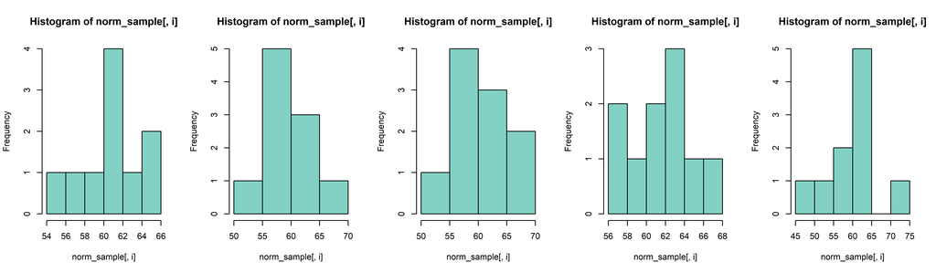

```r
par(mfrow=c(1,5))
for(i in 1:5) hist(norm_sample[,i], col = "#83D1C4")
```

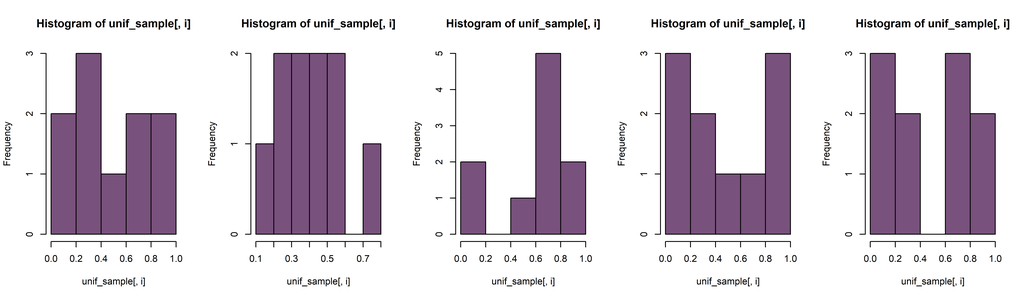

```r
for(i in 1:5) hist(unif_sample[,i], col = "#78517C")
```

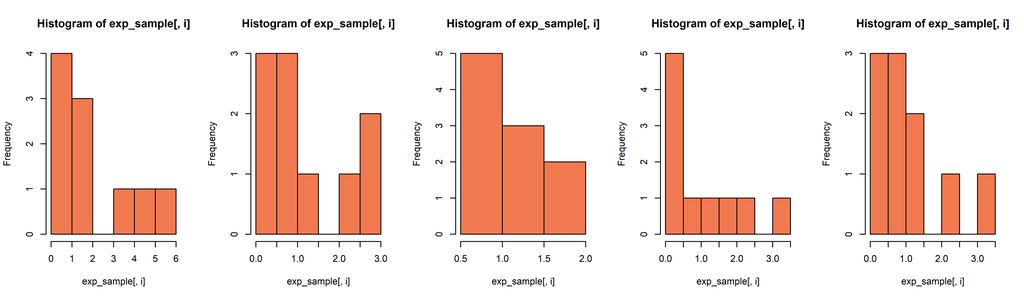

```r
for(i in 1:5) hist(exp_sample[,i], col = "#F17950")
```

## 1.2 Nilai tengah

Selama ini kita sering melakukan sampling terhadap populasi yang diketahui parameternya, seperti mean dan simpangan bakunya. Namun umumnya kita tidak tahu parameter populasi, sehingga perlu dilakukan pendugaan terhadap parameter, yakni statistik. Untuk nilai tengah, maka statistiknya adalah xbar.

Untuk mengetahui apakah statistik merupakan penga tak bias dari parameter, maka kita bisa mencoba menghitung statistik pada setiap ulangan dan merata-ratakan hasilnya. Lalu dilihat, apakah nilainya berbeda jauh dengan nilai parameternya atau tidak.

Untuk ketakbiasan nilai tengah, saya akan menggunakan fungsi `apply` untuk menerapkan mean pada setiap ulangan (kolom). Namun, mari kita lihat sebarannya terlebih dahulu sebelum melihat ketakbiasannya.

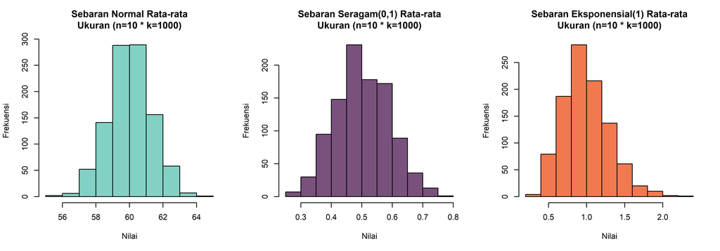

```r
par(mfrow = c(1, 3))
# Sebaran Normal
norm_mean <- apply(norm_sample, 2, mean)

hist(norm_mean,
     main = paste0("Sebaran Normal Rata-rata\nUkuran (n=", n," * k=", k, ")"),
     xlab = "Nilai", ylab = "Frekuensi", col = "#83D1C4")

# Sebaran Seragam(0,1)
unif_mean <- apply(unif_sample, 2, mean)

hist(unif_mean,
     main = paste0("Sebaran Seragam(0,1) Rata-rata\nUkuran (n=", n," * k=", k, ")"),
     xlab = "Nilai", ylab = "Frekuensi", col = "#78517C")

# Sebaran Eksponensial(1)
exp_mean <- apply(exp_sample, 2, mean)

hist(exp_mean,
     main = paste0("Sebaran Eksponensial(1) Rata-rata\nUkuran (n=", n," * k=", k, ")"),
     xlab = "Nilai", ylab = "Frekuensi", col = "#F17950")
```

Agar lebih jelas dan pasti akan ketakbiasannya, mari kita lihat nilai dibawah.

```r
cat(  "# Ketakbiasan Nilai tengah #",
    "\n                   Statistik   Parameter",
    "\nNormal (60,16)   :", mean(norm_mean), " \u2248", 60,
    "\nSeragam (0,1)    :", mean(unif_mean), "\u2248", (0+1)/2,
    "\nEksponensial (1) :", mean(exp_mean) , "\u2248", 1)
```

```
## # Ketakbiasan Nilai tengah #
##                    Statistik   Parameter
## Normal (60,16)   : 60.03852  ≈ 60
## Seragam (0,1)    : 0.5025261 ≈ 0.5
## Eksponensial (1) : 0.9921668 ≈ 1
```

Terlihat bahwa nilai statistiknya sudah sangat dekat dengan nilai parameternya, sehingga memang sudah teruji ketakbiasan nilai tengah dari setiap sebaran.

## 1.3 Ragam

Sama halnya dengan ketabiasan nilai tengah, untuk melihat ketakbiasan ragam bisa dilakukan dengan cara yang sama, bedanya hanya di fungsi `apply`, `FUN` yang digunakan adalah `var`, bukan `mean`.

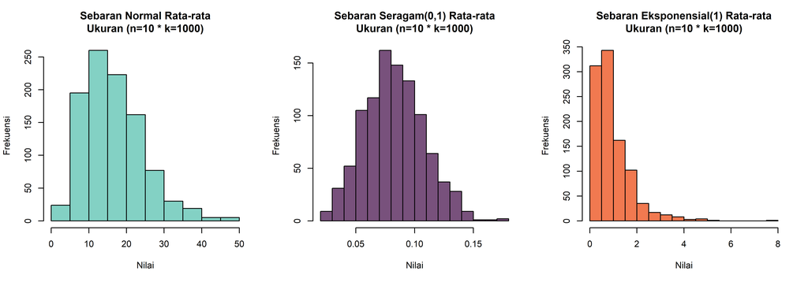

```r
set.seed(361)

par(mfrow = c(1, 3))
# Sebaran Normal
norm_var <- apply(norm_sample, 2, var)

hist(norm_var,
     main = paste0("Sebaran Normal Rata-rata\nUkuran (n=", n," * k=", k, ")"),
     xlab = "Nilai", ylab = "Frekuensi", col = "#83D1C4")

# Sebaran Seragam(0,1)
unif_var <- apply(unif_sample, 2, var)

hist(unif_var,
     main = paste0("Sebaran Seragam(0,1) Rata-rata\nUkuran (n=", n," * k=", k, ")"),
     xlab = "Nilai", ylab = "Frekuensi", col = "#78517C")

# Sebaran Eksponensial(1)
exp_var <- apply(exp_sample, 2, var)

hist(exp_var,
     main = paste0("Sebaran Eksponensial(1) Rata-rata\nUkuran (n=", n," * k=", k, ")"),
     xlab = "Nilai", ylab = "Frekuensi", col = "#F17950")
```

Agar lebih jelas dan pasti akan ketakbiasannya, mari kita lihat nilai dibawah.

```r
cat(  "# Ketakbiasan Ragam #",
    "\n                   Statistik    Parameter",
    "\nNormal (60,16)   :", mean(norm_var), "   \u2248", 16,
    "\nSeragam (0,1)    :", mean(unif_var), "\u2248", (1-0)^2/12,
    "\nEksponensial (1) :", mean(exp_var) , " \u2248", 1)
```

```
## # Ketakbiasan Ragam #
##                    Statistik    Parameter
## Normal (60,16)   : 16.5004    ≈ 16
## Seragam (0,1)    : 0.08250446 ≈ 0.08333333
## Eksponensial (1) : 0.9558471  ≈ 1
```

Terlihat bahwa nilai statistiknya sudah dekat dengan nilai parameternya, sehingga memang sudah teruji ketakbiasan ragam dari setiap sebaran.

# 2 Penduga Selang Kepercayaan

## 2.1 Jenis Populasi

Saya akan mencobakan bagaimana pengaruh besarnya ukuran contoh terhadap penduga selang kepercayaan pada populasi sebaran normal, seragam, dan eksponensial(1). Sama seperti sebelumnya, strategi percontohan yang digunakan adalah populasi takhingga, sehingga untuk mengambil sample nya langsung dari pembangkitan fungsi r nya. Ukuran contoh yang akan digunakan adalah 10, 30, dan 100. Parameter tiap populasinya pun sama seperti sebelumnya, yakni:

| Sebaran | Nilai tengah | Ragam |
| --- | --- | --- |
| Normal (60, 16) | $\mu=60$ | $\sigma^2=16$ |
| Seragam (0, 1) | $\frac{a+b}{2}=0.5$ | $\frac{(b-a)^2}{12} \approx 0.08334$ |
| Eksponensial (1) | $\theta=1$ | $\theta^2=1$ |

> Berikut merupakan hasil dari pembangkitan bilangan acak populasinya:

### 2.1.1 Normal

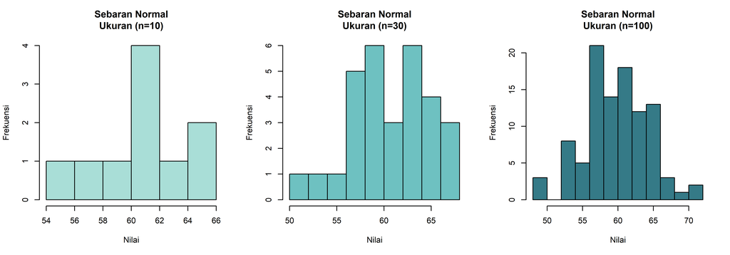

```r
set.seed(361)
sample_n <- c(10, 30, 100)

norm_samples <- lapply(sample_n, function(n) rnorm(n, mean=60, sd=4))

par(mfrow = c(1, 3))
hist(norm_samples[[1]],
     main = paste0("Sebaran Normal\nUkuran (n=", sample_n[[1]], ")"),
     xlab = "Nilai", ylab = "Frekuensi", col = "#a9ded7")

hist(norm_samples[[2]],
     main = paste0("Sebaran Normal\nUkuran (n=", sample_n[[2]], ")"),
     xlab = "Nilai", ylab = "Frekuensi", col = "#6ec1c1")

hist(norm_samples[[3]],
     main = paste0("Sebaran Normal\nUkuran (n=", sample_n[[3]], ")"),
     xlab = "Nilai", ylab = "Frekuensi", col = "#357a87")
```

### 2.1.2 Seragam

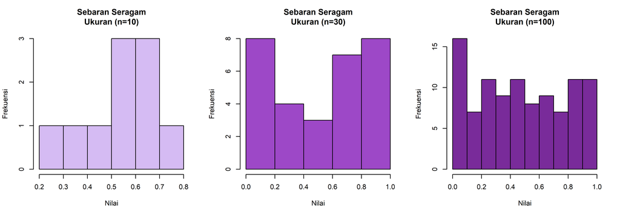

```r
set.seed(361)

unif_samples <- lapply(sample_n, function(n) runif(n, min=0, max=1))

par(mfrow = c(1, 3))
hist(unif_samples[[1]],
     main = paste0("Sebaran Seragam\nUkuran (n=", sample_n[[1]], ")"),
     xlab = "Nilai", ylab = "Frekuensi", col = "#d5bbf3")

hist(unif_samples[[2]],
     main = paste0("Sebaran Seragam\nUkuran (n=", sample_n[[2]], ")"),
     xlab = "Nilai", ylab = "Frekuensi", col = "#9d48c7")

hist(unif_samples[[3]],
     main = paste0("Sebaran Seragam\nUkuran (n=", sample_n[[3]], ")"),
     xlab = "Nilai", ylab = "Frekuensi", col = "#792b9a")
```

### 2.1.3 Eksponensial (1)

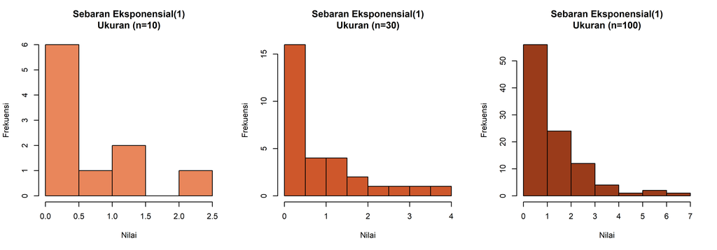

```r
set.seed(361)

exp_samples <- lapply(sample_n, function(n) rexp(n, rate=1))

par(mfrow = c(1, 3))
hist(exp_samples[[1]],
     main = paste0("Sebaran Eksponensial(1)\nUkuran (n=", sample_n[[1]], ")"),
     xlab = "Nilai", ylab = "Frekuensi", col = "#e9865b")

hist(exp_samples[[2]],
     main = paste0("Sebaran Eksponensial(1)\nUkuran (n=", sample_n[[2]], ")"),
     xlab = "Nilai", ylab = "Frekuensi", col = "#ce572b")

hist(exp_samples[[3]],
     main = paste0("Sebaran Eksponensial(1)\nUkuran (n=", sample_n[[3]], ")"),
     xlab = "Nilai", ylab = "Frekuensi", col = "#9a3b1a")
```

## 2.2 Pendugaan selang

Pendugaan selang kepercayaan dilakukan dengan formula $\bar x \pm (2 \times \sigma_\bar x)$, dimana $\sigma_\bar x = \sigma / \sqrt{n}$.

### 2.2.1 Normal

```r
mean_norm <- sapply(lapply(norm_samples, mean), function(x) x)
mean_unif <- sapply(lapply(unif_samples, mean), function(x) x)
mean_exp  <- sapply(lapply(exp_samples, mean), function(x) x)

# Parameter sd populasi
norm_sd <- sqrt(16)
unif_sd <- sqrt((1-0)^2 /12)
exp_sd <- sqrt(1)

# Statistik sd sample Normal
norm_sk <- c()
norm_sk[1] <- norm_sd /sqrt(sample_n[[1]])
norm_sk[2] <- norm_sd /sqrt(sample_n[[2]])
norm_sk[3] <- norm_sd /sqrt(sample_n[[3]])

cat("# Pendugaan SK Normal(60,16) #",
    "\n        Nilai tengah     SK",
    "\nn=10  :",mean_norm[1], "    \u00B1   ( 2 \u00D7", norm_sk[1], ")",
    "\nn=30  :",mean_norm[2], "     \u00B1   ( 2 \u00D7", norm_sk[2], ")",
    "\nn=100 :",mean_norm[3], "    \u00B1   ( 2 \u00D7", norm_sk[3], ")")
```

```
## # Pendugaan SK Normal(60,16) #
##         Nilai tengah     SK
## n=10  : 60.81104     ±   ( 2 × 1.264911 )
## n=30  : 60.6532      ±   ( 2 × 0.7302967 )
## n=100 : 59.85236     ±   ( 2 × 0.4 )
```

### 2.2.2 Seragam

```r
# Statistik sd sample Sergam
unif_sk <- c()
unif_sk[1] <- unif_sd /sqrt(sample_n[[1]])
unif_sk[2] <- unif_sd /sqrt(sample_n[[2]])
unif_sk[3] <- unif_sd /sqrt(sample_n[[3]])

cat("# Pendugaan SK Seragam(0,1) #",
    "\n        Nilai tengah      SK",
    "\nn=10  :",mean_unif[1], "    \u00B1   ( 2 \u00D7", unif_sk[1], ")",
    "\nn=30  :",mean_unif[2], "    \u00B1   ( 2 \u00D7", unif_sk[2], ")",
    "\nn=100 :",mean_unif[3], "    \u00B1   ( 2 \u00D7", unif_sk[3], ")")
```

```
## # Pendugaan SK Seragam(0,1) #
##         Nilai tengah      SK
## n=10  : 0.5342156     ±   ( 2 × 0.09128709 )
## n=30  : 0.5147594     ±   ( 2 × 0.05270463 )
## n=100 : 0.4805532     ±   ( 2 × 0.02886751 )
```

### 2.2.3 Eksponensial (1)

```r
# Statistik sd sample Eksponensial
exp_sk <- c()
exp_sk[1] <- exp_sd /sqrt(sample_n[[1]])
exp_sk[2] <- exp_sd /sqrt(sample_n[[2]])
exp_sk[3] <- exp_sd /sqrt(sample_n[[3]])

cat("# Pendugaan SK Eksponensial(1) #",
    "\n        Nilai tengah      SK",
    "\nn=10  :",mean_exp[1], "    \u00B1   ( 2 \u00D7", exp_sk[1], ")",
    "\nn=30  :",mean_exp[2], "    \u00B1   ( 2 \u00D7", exp_sk[2], ")",
    "\nn=100 :",mean_exp[3], "     \u00B1   ( 2 \u00D7", exp_sk[3], ")")
```

```
## # Pendugaan SK Eksponensial(1) #
##         Nilai tengah      SK
## n=10  : 0.6659931     ±   ( 2 × 0.3162278 )
## n=30  : 0.9203823     ±   ( 2 × 0.1825742 )
## n=100 : 1.244227      ±   ( 2 × 0.1 )
```

## 2.3 Kesimpulan

Terlihat dari hasil pendugaan selang tiap sebaran dan ukuran contoh menunjukkan bahwa dengan **meningkatnya ukuran sampel**, selang kepercayaan **cenderung menyempit**, atau dengan kata lain, kita menjadi **lebih yakin** tentang pendugaan **nilai tengah populasi**.